# Practical Machine Learning Project

Sven Boekhoven

Saturday, January 24, 2015

### Background

Using devices such as Jawbone Up, Nike FuelBand, and Fitbit it is now possible to collect a large amount of data about personal activity relatively inexpensively. These type of devices are part of the quantified self movement - a group of enthusiasts who take measurements about themselves regularly to improve their health, to find patterns in their behavior, or because they are tech geeks. One thing that people regularly do is quantify how much of a particular activity they do, but they rarely quantify how well they do it. In this project, your goal will be to use data from accelerometers on the belt, forearm, arm, and dumbell of 6 participants. They were asked to perform barbell lifts correctly and incorrectly in 5 different ways. More information is available from the website here: http://groupware.les.inf.puc-rio.br/har (see the section on the Weight Lifting Exercise Dataset).

### Data

The training data for this project are available here: [https://d396qusza40orc.cloudfront.net/predmachlearn/pml-training.csv]

The test data are available here: [https://d396qusza40orc.cloudfront.net/predmachlearn/pml-testing.csv]

### Citation

The data for this project come from this source: [http://groupware.les.inf.puc-rio.br/har].

### Goal

The goal is to find a model that can predicht the classes below based on the sensor data of an activity.

- exactly according to the specification (Class A)
- throwing the elbows to the front (Class B)
- lifting the dumbbell only halfway (Class C)
- lowering the dumbbell only halfway (Class D)
- throwing the hips to the front (Class E)

## Loading data

Below the code for loading the data (which was already downloaded to my harddrive).

```r
library("dplyr")
library("caret")
library("tidyr")

set.seed(54356)

pml.training <- read.csv("pml-training.csv", na.strings = c("NA","#DIV/0!", ""), dec = ".")
```

## Cleaning data

The data needs to be cleaned before it can be used for modelling. I tried several different ways of cleanng the data before I came up with the following steps:

1. Remove new_window == yes observations because these seem to be aggragates of other column.
2. Remove the first columns (id, timestamps, subject name) because they are not usefull in predicting.
3. Remove all columns with NA values.

```r
x <- pml.training %>% filter(new_window == "no")
x <- x[8:length(x)]
x <- x[ , ! apply(x ,2 ,function(x) any(is.na(x)) ) ]
```

## Creating training and testset for cross validation

The assignment provides a training and testset, however, the testset is not really a testset, but more a submission set. To be able to validate the model the provided trainingset will be split in a training and testset for the modelling.

```r
inTrain <- createDataPartition(y=x$classe,
                               p=0.6, list=FALSE)
trainingset <- subset(x[inTrain,])
testset <- subset(x[-inTrain,])
```

## Cross validation

```r
cvCtrl <- trainControl(method = "repeatedcv", repeats = 3)
```

# Decision Tree Model

```r
model_rpart <- train(classe ~ ., data=trainingset, method="rpart", tuneLength = 30, trControl = cvCtrl)
model_rpart$finalModel
```

```
## n= 11532
##
## node), split, n, loss, yval, (yprob)
##       * denotes terminal node
##
##     1) root 11532 8249 A (0.28 0.19 0.17 0.16 0.18)
##       2) roll_belt< 130.5 10561 7284 A (0.31 0.21 0.19 0.18 0.11)
##         4) pitch_forearm< -33.95 937    5 A (0.99 0.0053 0 0 0) *
##         5) pitch_forearm>=-33.95 9624 7279 A (0.24 0.23 0.21 0.2 0.12)
##          10) magnet_dumbbell_y< 436.5 8067 5776 A (0.28 0.18 0.24 0.19 0.1)
##            20) roll_forearm< 121.5 4996 2948 A (0.41 0.18 0.19 0.17 0.059)
##              40) magnet_dumbbell_z< -27.5 1649  524 A (0.68 0.2 0.013 0.069 0.034)
##                80) roll_forearm>=-136.5 1345  254 A (0.81 0.16 0.013 0.013 0.0059)
##                 160) accel_dumbbell_y>=-51.5 1263  177 A (0.86 0.13 0.00079 0.013 0) *
##                 161) accel_dumbbell_y< -51.5 82   30 B (0.061 0.63 0.21 0 0.098) *
##                81) roll_forearm< -136.5 304  181 B (0.11 0.4 0.0099 0.32 0.16)
##                 162) gyros_arm_y>=0.935 116   24 B (0 0.79 0 0 0.21) *
##                 163) gyros_arm_y< 0.935 188   92 D (0.18 0.16 0.016 0.51 0.13) *
##              41) magnet_dumbbell_z>=-27.5 3347 2424 A (0.28 0.17 0.27 0.21 0.071)
##                82) yaw_belt>=169.5 406   47 A (0.88 0.057 0 0.057 0.0025) *
##                83) yaw_belt< 169.5 2941 2026 C (0.19 0.18 0.31 0.23 0.08)
##                 166) accel_dumbbell_y>=-40.5 2534 1854 D (0.22 0.2 0.22 0.27 0.085)
##                   332) pitch_belt< -42.95 310   61 B (0.026 0.8 0.11 0.039 0.026) *
##                   333) pitch_belt>=-42.95 2224 1556 D (0.25 0.12 0.24 0.3 0.094)
##                     666) roll_belt>=125.5 536  230 C (0.39 0.017 0.57 0.017 0.0056)
##                      1332) magnet_belt_z< -323 186    5 A (0.97 0 0.011 0 0.016) *
##                      1333) magnet_belt_z>=-323 350   46 C (0.08 0.026 0.87 0.026 0) *
##                     667) roll_belt< 125.5 1688 1029 D (0.2 0.15 0.13 0.39 0.12)
##                      1334) pitch_belt>=1.3 1055  801 A (0.24 0.22 0.15 0.22 0.17)
##                        2668) accel_dumbbell_z< 26.5 675  435 A (0.36 0.12 0.22 0.26 0.034)
##                          5336) yaw_forearm>=-90.65 494  254 A (0.49 0.16 0.24 0.081 0.036)
##                           10672) magnet_forearm_z>=-174 340  103 A (0.7 0.13 0.024 0.11 0.041)
##                             21344) magnet_dumbbell_x>=-549.5 291   58 A (0.8 0.045 0.027 0.12 0.0069)
##                               42688) total_accel_belt< 8 264   31 A (0.88 0.049 0.03 0.03 0.0076) *
##                               42689) total_accel_belt>=8 27    0 D (0 0 0 1 0) *
##                             21345) magnet_dumbbell_x< -549.5 49   17 B (0.082 0.65 0 0.02 0.24) *
##                           10673) magnet_forearm_z< -174 154   43 C (0.019 0.21 0.72 0.026 0.026) *
##                          5337) yaw_forearm< -90.65 181   43 D (0 0.033 0.18 0.76 0.028) *
##                        2669) accel_dumbbell_z>=26.5 380  220 E (0.037 0.39 0.011 0.14 0.42)
##                          5338) roll_dumbbell< 36.03719 136   24 B (0.037 0.82 0.029 0.044 0.066) *
```

[output cut: 37 more lines]

```
##                 175) accel_dumbbell_z< 30.5 394   78 D (0.079 0.018 0.025 0.8 0.076) *
##          11) magnet_dumbbell_y>=436.5 1557  765 B (0.035 0.51 0.04 0.22 0.2)
##            22) total_accel_dumbbell>=5.5 1128  402 B (0.048 0.64 0.054 0.019 0.24)
##              44) roll_belt>=-0.575 942  216 B (0.057 0.77 0.065 0.022 0.085)
##                88) magnet_belt_y>=586.5 881  155 B (0.06 0.82 0.069 0.024 0.023)
##                 176) yaw_dumbbell< -65.84966 93   40 A (0.57 0.23 0.086 0.12 0) *
##                 177) yaw_dumbbell>=-65.84966 788   83 B (0 0.89 0.067 0.013 0.025) *
##                89) magnet_belt_y< 586.5 61    1 E (0.016 0 0 0 0.98) *
##              45) roll_belt< -0.575 186    0 E (0 0 0 0 1) *
##            23) total_accel_dumbbell< 5.5 429  108 D (0 0.15 0.0047 0.75 0.093)
##              46) yaw_belt< -2.825 62    0 B (0 1 0 0 0) *
##              47) yaw_belt>=-2.825 367   46 D (0 0.011 0.0054 0.87 0.11)
##                94) roll_belt< 123 330    9 D (0 0.012 0.0061 0.97 0.0091) *
##                95) roll_belt>=123 37    0 E (0 0 0 0 1) *
##       3) roll_belt>=130.5 971    6 E (0.0062 0 0 0 0.99) *
```

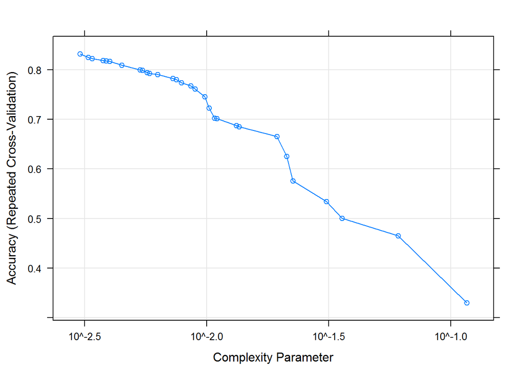

```r
plot(model_rpart, scales = list(x = list(log = 10)))
```

# Random forest model

```r
model_rf <- train(classe ~ ., data=trainingset, method="rf", trControl = cvCtrl)
model_rf
```

```
## Random Forest
##
## 11532 samples
##    52 predictor
##     5 classes: 'A', 'B', 'C', 'D', 'E'
##
## No pre-processing
## Resampling: Cross-Validated (10 fold, repeated 3 times)
##
## Summary of sample sizes: 10379, 10379, 10379, 10379, 10379, 10381, ...
##
## Resampling results across tuning parameters:
##
##   mtry  Accuracy   Kappa      Accuracy SD  Kappa SD
##    2    0.9895654  0.9867978  0.002457697  0.003110145
##   27    0.9897964  0.9870905  0.002492139  0.003154476
##   52    0.9786392  0.9729758  0.003471252  0.004392370
##
## Accuracy was used to select the optimal model using  the largest value.
## The final value used for the model was mtry = 27.
```

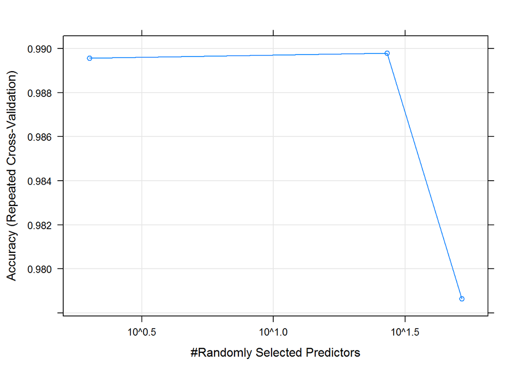

```r
plot(model_rf, scales = list(x = list(log = 10)))
```

# Confusion matrix for both models

The plots below show that the random forest model yields a better result.

## Descision tree

```r
predictions_rparttest <- predict(model_rpart, testset)
confusionMatrix(predictions_rparttest, testset$classe)
```

```
## Confusion Matrix and Statistics
##
##           Reference
## Prediction    A    B    C    D    E
##          A 2019  174   11   59   14
##          B   47 1028   91   36   72
##          C   35  142 1121   56   86
##          D   65   57   88 1046   79
##          E   22   86   29   61 1160
##
## Overall Statistics
##
##                Accuracy : 0.8295
##                  95% CI : (0.8209, 0.8379)
##     No Information Rate : 0.2847
##     P-Value [Acc > NIR] : < 0.00000000000000022
##
##                   Kappa : 0.7842
##  Mcnemar's Test P-Value : < 0.00000000000000022
##
## Statistics by Class:
##
##                      Class: A Class: B Class: C Class: D Class: E
## Sensitivity            0.9228   0.6913   0.8366   0.8315   0.8221
## Specificity            0.9531   0.9603   0.9497   0.9550   0.9684
## Pos Pred Value         0.8867   0.8069   0.7785   0.7835   0.8542
## Neg Pred Value         0.9687   0.9284   0.9649   0.9666   0.9603
## Prevalence             0.2847   0.1935   0.1744   0.1637   0.1836
## Detection Rate         0.2628   0.1338   0.1459   0.1361   0.1510
## Detection Prevalence   0.2963   0.1658   0.1874   0.1737   0.1767
## Balanced Accuracy      0.9379   0.8258   0.8931   0.8933   0.8953
```

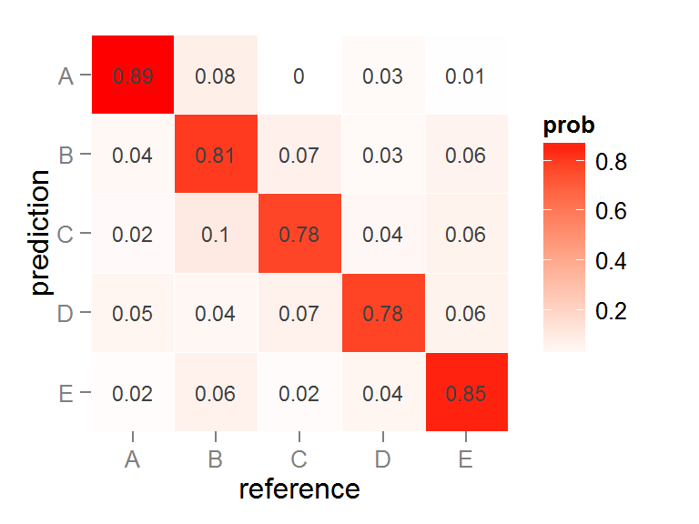

```r
conf_rpart <- as.data.frame(confusionMatrix(predictions_rparttest, testset$classe)[2])
conf_rpart <- conf_rpart %>% rename(prediction = table.Prediction, reference = table.Reference, count = table.Freq) %>%
        arrange(desc(prediction)) %>% group_by(prediction) %>% mutate(prob = count/sum(count)) %>% ungroup
ggplot(conf_rpart, aes(reference, prediction)) +
        geom_tile(aes(fill = prob), colour = "white") +
        geom_text(aes(fill = prob, label = round(prob, 2)), size=3, colour="grey25") +
        scale_fill_gradient(low = "white", high = "red") +
        scale_x_discrete(expand = c(0, 0)) +
        scale_y_discrete(expand = c(0, 0), limits = c("E","D","C","B","A"))
```

## Random forest

```r
predictions_rftest <- predict(model_rf, testset)
confusionMatrix(predictions_rftest, testset$classe)
```

```
## Confusion Matrix and Statistics
##
##           Reference
## Prediction    A    B    C    D    E
##          A 2183   17    0    0    0
##          B    4 1463    7    2    0
##          C    0    7 1327   16    1
##          D    0    0    6 1239    7
##          E    1    0    0    1 1403
##
## Overall Statistics
##
##                Accuracy : 0.991
##                  95% CI : (0.9886, 0.993)
##     No Information Rate : 0.2847
##     P-Value [Acc > NIR] : < 0.00000000000000022
##
##                   Kappa : 0.9886
##  Mcnemar's Test P-Value : NA
##
## Statistics by Class:
##
##                      Class: A Class: B Class: C Class: D Class: E
## Sensitivity            0.9977   0.9839   0.9903   0.9849   0.9943
## Specificity            0.9969   0.9979   0.9962   0.9980   0.9997
## Pos Pred Value         0.9923   0.9912   0.9822   0.9896   0.9986
## Neg Pred Value         0.9991   0.9961   0.9979   0.9970   0.9987
## Prevalence             0.2847   0.1935   0.1744   0.1637   0.1836
## Detection Rate         0.2841   0.1904   0.1727   0.1612   0.1826
## Detection Prevalence   0.2863   0.1921   0.1758   0.1629   0.1828
## Balanced Accuracy      0.9973   0.9909   0.9933   0.9914   0.9970
```

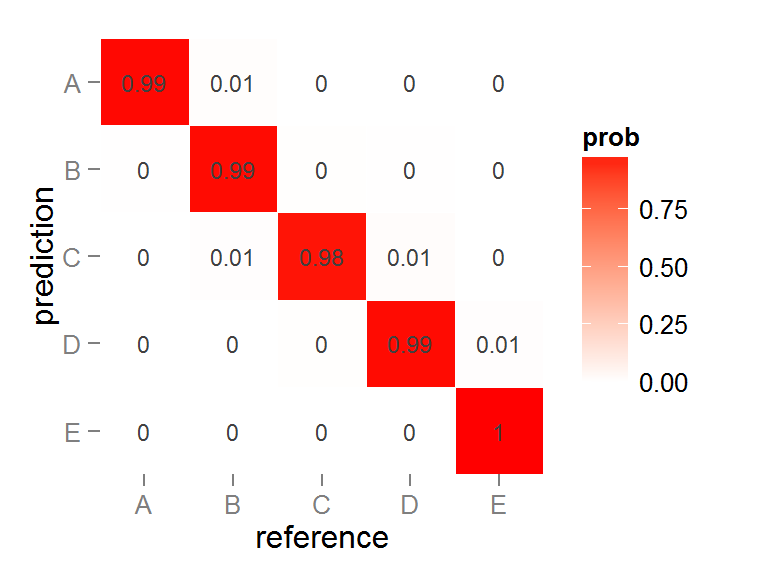

```r
conf_rf <- as.data.frame(confusionMatrix(predictions_rftest, testset$classe)[2])
conf_rf <- conf_rf %>% rename(prediction = table.Prediction, reference = table.Reference, count = table.Freq) %>%
        arrange(desc(prediction)) %>% group_by(prediction) %>% mutate(prob = count/sum(count)) %>% ungroup
ggplot(conf_rf, aes(reference, prediction)) +
        geom_tile(aes(fill = prob), colour = "white") +
        geom_text(aes(fill = prob, label = round(prob, 2)), size=3, colour="grey25") +
        scale_fill_gradient(low = "white", high = "red") +
        scale_x_discrete(expand = c(0, 0)) +
        scale_y_discrete(expand = c(0, 0), limits = c("E","D","C","B","A"))
```

## Sample Error of random forest

```r
model_rf$finalModel ## in-sample
```

```
##
## Call:
##  randomForest(x = x, y = y, mtry = param$mtry)
##                Type of random forest: classification
##                      Number of trees: 500
## No. of variables tried at each split: 27
##
##         OOB estimate of  error rate: 0.96%
## Confusion matrix:
##      A    B    C    D    E class.error
## A 3275    5    2    1    0 0.002436796
## B   25 2196    8    2    0 0.015688032
## C    0   16 1988    8    0 0.011928429
## D    0    1   29 1858    1 0.016410799
## E    0    2    5    6 2104 0.006140765
```

```r
confusionMatrix(predictions_rftest, testset$classe)[3] ## out-of-sample
```

```
## $overall
##       Accuracy          Kappa  AccuracyLower  AccuracyUpper   AccuracyNull
##      0.9910203      0.9886389      0.9886492      0.9930067      0.2847475
## AccuracyPValue  McnemarPValue
##      0.0000000            NaN
```

# Prediction using Random forest model

As shown above the random forest model was the best to predict. So this model is used to predict the class for the submission.

The heatmap shows that the prediction has a high probability for serveral observation, but is also less certain for others. We will see what the result is when the anwsers are submitted.

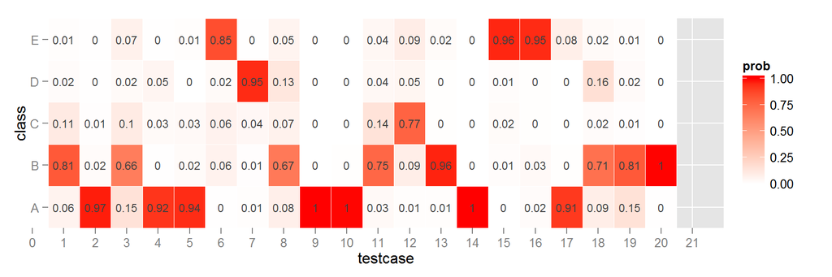

```r
bestfit <- model_rf

pml.submission <- read.csv("pml-testing.csv", na.strings = c("NA","#DIV/0!", ""), dec = ".")

predprob <- predict(bestfit, pml.submission, type = "prob")
predprob$testcase <- 1:nrow(predprob)
predprob <- gather(predprob, "class", "prob", 1:5)
ggplot(predprob, aes(testcase, class)) +
        geom_tile(aes(fill = prob), colour = "white") +
        geom_text(aes(fill = prob, label = round(prob, 2)), size=3, colour="grey25") +
        scale_fill_gradient(low = "white", high = "red") +
        scale_x_discrete(expand = c(0, 0)) +
        scale_y_discrete(expand = c(0, 0))
```

```r
final_predictions <- predict(bestfit, pml.submission)
final_predictions
```

```
##  [1] B A B A A E D B A A B C B A E E A B B B
## Levels: A B C D E
```

Below the submission files are generated

```r
pml_write_files = function(x){
        n = length(x)
        for(i in 1:n){
                filename = paste0("problem_id_",i,".txt")
                write.table(x[i],file=filename,quote=FALSE,row.names=FALSE,col.names=FALSE)
        }
}

pml_write_files(final_predictions)
```